# Royston’s Quarto Introduction Website

## Background

I am Royston a student at Singapore Institute of Technology (SIT) pursuing a degree in Artificial Intelligence.

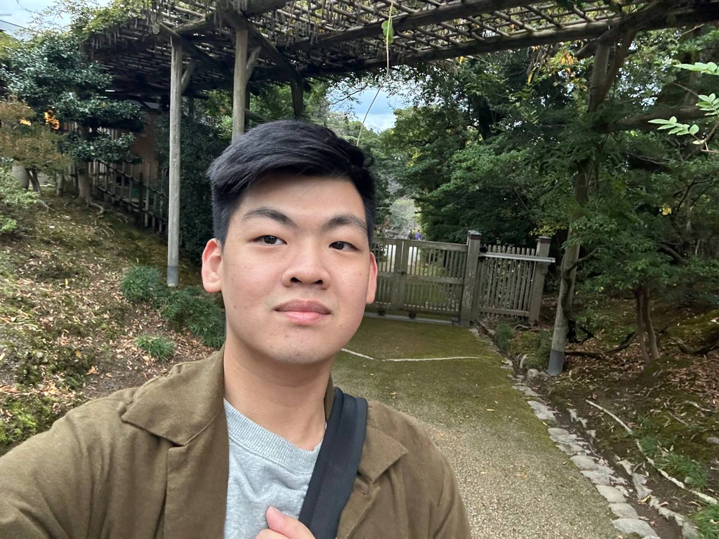

## Interests

#### Music

Back in Poly I used to play in Garage Band which is a cover band CCA where I played as a guitarist. I have done a number of performances and I have also done a few recordings. I am currently casually playing guitar and I am looking to get into sound mixing and recording as I am interested in the technical side of music.

[video not shown]

#### Gaming

I am a casual gamer and I play games like Valorant, Dota, Minecraft. I am also interested in game development and I have dabbled in Unity and Unreal Engine. I am looking to learn more about game development as I find it fascinating how games are made and the technology behind it. I have friends that have gone this path and I have learned alot from their experiences on the actual industry.

#### Hobbies

Cooking - Japanese styled food Cycling - Currently using a carbon fiber Bike Badminton - Havent bought a racket yet